# 第3章: 測定 (3.5. 政治的分極化を測定する / 3.6. 2変量関係の要約)

今井耕介 著 『社会科学のためのデータ分析入門 (QSS)』

2026-03-09

# 3.5 政治的分極化を測定する / 3.6 2変量関係の要約

# 政治的分極化 (Political Polarization)

- **問い**: 米国の政治家は、時間の経過とともに思想的に離れていっているか？
- **測定**: 議員の投票行動に基づく思想スコア (DW-NOMINATE) を使用。
  - 第1次元: 経済的自由主義/保守主義
  - 第2次元: 人種問題・社会問題
- **2変量関係**: 2つの変数が互いにどのように関連しているかを、散布図や相関係数を用いて分析する。

# 3.6.1 散布図 (Scatter Plot)

# 思想スコアの可視化 (1): データの準備

```r
# 1. 議会投票データの読み込み
congress <- read.csv("congress.csv")

# 2. 共和党 (Republican) と民主党 (Democrat) にデータを分ける
rep <- subset(congress, subset = (party == "Republican"))
dem <- subset(congress, subset = (party == "Democrat"))

# 3. 第80議会と第112議会のデータを抽出
dem80 <- subset(dem, subset = (congress == 80))
rep80 <- subset(rep, subset = (congress == 80))
dem112 <- subset(dem, subset = (congress == 112))
rep112 <- subset(rep, subset = (congress == 112))
```

# 散布図の作成 (第80議会): コード

```r
# 散布図のプロット範囲とラベルの設定
lim <- c(-1.5, 1.5)
xlab <- "Economic liberalism/conservatism"
ylab <- "Racial liberalism/conservatism"

# 1. 民主党議員を青い丸 (pch=16) でプロット
plot(dem80$dwnom1, dem80$dwnom2, pch = 16, col = "blue",
     xlim = lim, ylim = lim, xlab = xlab, ylab = ylab, main = "80th Congress")

# 2. 共和党議員を赤い三角 (pch=17) で重ねてプロット
points(rep80$dwnom1, rep80$dwnom2, pch = 17, col = "red")
```

# 散布図の作成 (第80議会): 描画結果

[figure not shown]

# 散布図の作成 (第112議会): 描画結果

[figure not shown]

- **観察**: 第80議会（1940年代）に比べ、第112議会（2010年代）では両党が思想的に大きく離れている（分極化）。

# 分極化の推移: コード

```r
# 1. 各議会ごとの両党の中央値を計算 (tapplyを使用)
dem.median <- tapply(dem$dwnom1, dem$congress, median)
rep.median <- tapply(rep$dwnom1, rep$congress, median)

# 2. 民主党の中央値の推移を折れ線グラフで描画
plot(names(dem.median), dem.median, col = "blue", type = "l",
     xlim = c(80, 115), ylim = c(-1, 1), xlab = "Congress",
     ylab = "Median DW-NOMINATE score")

# 3. 共和党の推移を重ねる
lines(names(rep.median), rep.median, col = "red")
```

# 分極化の推移: 描画結果

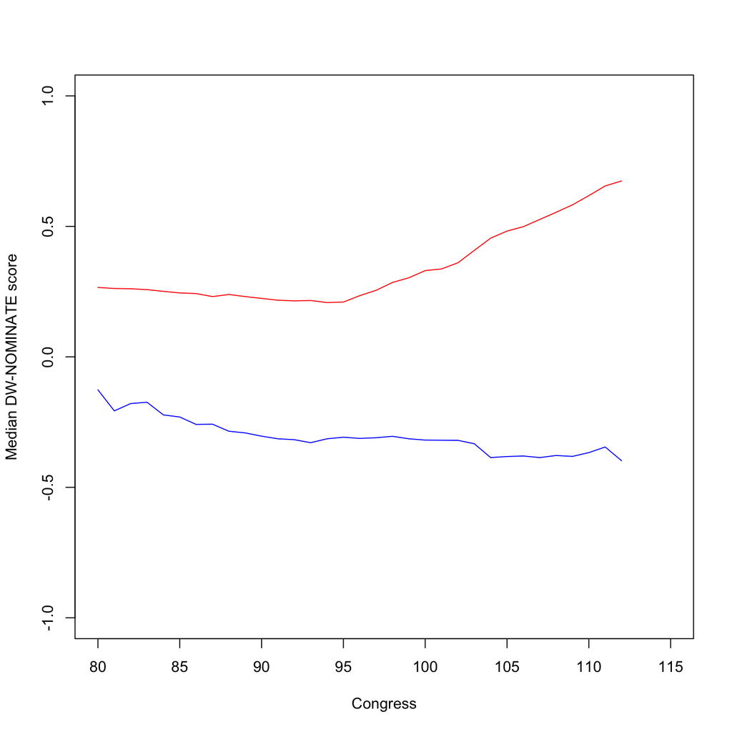

# 3.6.2 相関 (Correlation)

# 分極化と経済的不平等の関係

- **問い**: 政治の分極化は、経済的な格差と連動しているか？
- ジニ係数（格差の指標）との相関を調べます。

```r
# 1. ジニ係数データの読み込み
gini <- read.csv("USGini.csv")

# 2. 分極化の指標（共和党中央値 - 民主党中央値）との相関を計算
# 隔年（議会が開かれる年）のジニ係数のみを抽出して比較
cor(gini$gini[seq(from = 2, to = nrow(gini), by = 2)],
    rep.median - dem.median)
```

```
## [1] 0.9418128
```

- **解釈**: 相関係数が約 0.94 と非常に高く、強い正の相関があることがわかる。

# 3.6.3 まとめ

# このセクションのまとめ

- **散布図**: 2つの数値変数の関係を視覚化する最も基本的な方法。
- **分極化の測定**: 中央値の差や散布図上の分布の変化から、思想的な隔たりを捉える。
- **相関係数**: 2変数の線形な関係の強さを数値化する（-1 から 1）。
- **格差と政治**: 経済的な不平等と政治的な対立が強く関連している可能性を示唆。
- **Rの操作**:
  - `plot()`, `points()`, `lines()` による重ね書き。
  - `tapply()` によるグループ別集計。
  - `cor()` による相関の算出。
  - `seq()` を用いたデータの規則的な抽出。